# Experiment 2

2024-10-31

# Overview

This page contains the analysis for experiment 2 (the three alternative forced choice task). As we discussed, I’ve included the code and comments in this document so that the analysis pipeline is viewable. Within this page, I’ve included several section including a statistical analysis section, a section about prior selection, a model reporting section, pairwise comparisons, and, finally, a sensitivity analysis (for the appendix).

The following code loads the needed libraries and the data from experiment 1. This data was used to create priors.

This code takes both the member and nonmember prompts and returns the total number of trials in the data set for each condition, to be used later in the determination of proprotions of each predicted repsonse based on the ratings.

```r
# make a grouped dataframe to identify the total number of trials per main condition (denominator of probabiliy)
total_possible_nm_df = nonmember_tidy %>%
  group_by(CategoryType) %>%
  summarise(n = n())

total_possible_m_df = member_tidy %>%
  group_by(CategoryType) %>%
  summarise(n = n())

# assign them to an object
nm_total = total_possible_nm_df$n[1]
m_total = total_possible_m_df$n[1]
```

This is how the priors for experiment 2 were created based on the data from experiment 1. The rating data was conditionally mutated depending upon whether it came from the `nonmember_tidy` or `member_tidy` data set. For the `nonmember` data, ratings of 1 or 2 were considered to be “is” answers, 3, 4 and 5 were “both” answers, and 6 and 7 were “is not” answers. On the other hand, the `member_tidy` predicted answers were essentially the opposite: 1 and 2 were predicted to be “is not” answers, 3, 4, 5 and were “both” answers, and 6 and 7 were “is” answers.

```r
# Mutate the original data conditionally
## For nonmember, 1 and 2 are ratings are predicted to be "is" answers.
## 3,4,and 5 are predicted to be "both" answers.
## 6 and 7 are predicted to be "is not" answers.
nonmember_tidy_mutated = nonmember_tidy %>%
  mutate(predicted_answer = case_when(
    Rating == 1 | Rating == 2 ~ "is",
    Rating == 3 | Rating == 4 | Rating == 5 ~ "both",
    Rating == 6 | Rating == 7 ~ "is_not",
  ))
## For member, it is revered from nonmember:
## 1 and 2 are ratings are predicted to be "is not" answers.
## 3,4,and 5 are predicted to be "both" answers.
## 6 and 7 are predicted to be "is" answers.
member_tidy_mutated = member_tidy %>%
  mutate(predicted_answer = case_when(
    Rating == 1 | Rating == 2 ~ "is_not",
    Rating == 3 | Rating == 4 | Rating == 5 ~ "both",
    Rating == 6 | Rating == 7 ~ "is",
  ))
```

Next, the data was grouped by the `CategoryType` and the `predicted_answer` (described above) to return the total number of answers for each type in the data for both nonmember and member data.

```r
# calculate the proportion of predicted is_not, both, and is answers for both member and non member data.
nonmember_tidy_mutated_grouped = nonmember_tidy_mutated %>%
  group_by(CategoryType, predicted_answer) %>%
  summarise(n_a = n())

member_tidy_mutated_grouped = member_tidy_mutated %>%
  group_by(CategoryType, predicted_answer) %>%
  summarise(n_b = n())

nonmember_tidy_mutated_grouped
```

```
## # A tibble: 15 × 3
## # Groups:   CategoryType [5]
##    CategoryType predicted_answer   n_a
##    <chr>        <chr>            <int>
##  1 Abstract     both                97
##  2 Abstract     is                  83
##  3 Abstract     is_not             102
##  4 Artifact     both                98
##  5 Artifact     is                  27
##  6 Artifact     is_not             157
##  7 Definite     both                11
##  8 Definite     is                   6
##  9 Definite     is_not              77
## 10 Natural      both                61
## 11 Natural      is                  13
## 12 Natural      is_not             208
## 13 Vague        both                67
## 14 Vague        is                  23
## 15 Vague        is_not               4
```

```r
member_tidy_mutated_grouped
```

```
## # A tibble: 15 × 3
## # Groups:   CategoryType [5]
##    CategoryType predicted_answer   n_b
##    <chr>        <chr>            <int>
##  1 Abstract     both               107
##  2 Abstract     is                  88
##  3 Abstract     is_not             105
##  4 Artifact     both                97
##  5 Artifact     is                  34
##  6 Artifact     is_not             169
##  7 Definite     both                 5
##  8 Definite     is                  11
##  9 Definite     is_not              84
## 10 Natural      both                83
## 11 Natural      is                  25
## 12 Natural      is_not             192
## 13 Vague        both                65
## 14 Vague        is                  30
## 15 Vague        is_not               5
```

Now, using the grouped data, a probability was generated by dividing the grouped totals by the total number possible in that category.

```r
# Join the member and nonmember data and calculate the proprotion of predicted responses relative to the total number of trials - our priors in probability.
data_for_priors = left_join(nonmember_tidy_mutated_grouped, member_tidy_mutated_grouped) %>%
  mutate(predicted_grp_prob = (n_a + n_b)/sum(m_total, nm_total))
```

The table below shows the probability of each of the 9 posible combinations of answer and condition.

```r
data_for_priors %>%
  filter(CategoryType == "Abstract" | CategoryType == "Artifact" | CategoryType == "Natural") %>%
  select(CategoryType, predicted_answer, predicted_grp_prob) %>%
  pivot_wider(names_from = predicted_answer, values_from = predicted_grp_prob) %>%
  knitr::kable(format = "pandoc", digits = 2)
```

| CategoryType | both | is | is_not |
| --- | --- | --- | --- |
| Abstract | 0.35 | 0.29 | 0.36 |
| Artifact | 0.34 | 0.10 | 0.56 |
| Natural | 0.25 | 0.07 | 0.69 |

To incorporate this information in the model, it was necessary to do some arithmetic. The model has two intercepts that are specified directly, and a third that is not. In addition to that, there are four fixed effects that we also can specify. The intercepts represent the probability of the choosing a given answer for the reference level, while the effects represent the change in the log-odds of the same answer going from one `CategoryType` to another. So, in our model, we have an intercept for “is” and “is not” that we specify, and the remaining probability space is probability of “both” for the reference level (`Value`). The effects specify both an intercept and an effect and are the difference in log-odds relative to the log-odds for that answer of `Value`.

To report this process, I would simply say something like this: In order specify our prior beliefs about the probabilities for each answer and category type, probabilities were converted to log-odds and calculated relative to a given reference level.

This process is one I don’t think is super necessary to get down in the weeds on (for the purpose of a paper or reporting), but I am happy to elaborate further if this is not clear/you are curious.

```r
sd = .5
is_int = paste0("normal(", qlogis(.29), ", ",sd,")")
intnot_int = paste0("normal(", qlogis(.36), ", ",sd,")")
is_art = paste0("normal(", 1.3, ", ",sd,")")
is_nat = paste0("normal(", 1.7, ", ",sd,")")
is_not_art = paste0("normal(", .81, ", ",sd,")")
is_not_nat = paste0("normal(", 1.38, ", ",sd,")")

prior_check = c(set_prior(is_int, class = "Intercept", dpar = "muIs"),
                set_prior(intnot_int, class = "Intercept", dpar = "muIsnot"),
                set_prior(is_art, class = "b", dpar = "muIs", coef = "CategoryTypeArtifact"),
                set_prior(is_nat, class = "b", dpar = "muIs", coef = "CategoryTypeNatural"),
                set_prior(is_not_art, class = "b", dpar = "muIsnot", coef = "CategoryTypeArtifact"),
                set_prior(is_not_nat, class = "b", dpar = "muIsnot", coef = "CategoryTypeNatural"))
```

Now, the data is loaded in for experiment 2 and the reference was set to `Value`. Next the model is fit. If your machine does not `brms` in R, this will probably not run. When it does run, this model takes a few minutes to fit (around 5).

```r
## Should fit this in a script and laod in in the rmd for the sake of time
senses_tidy = read.csv(here("data", "tidy", "senses_tidy.csv"))

senses_tidy$CategoryType = as.factor(senses_tidy$CategoryType)
senses_tidy$CategoryType = relevel(senses_tidy$CategoryType, ref = "Value")

b2 <- brm(Selection ~ CategoryType + (CategoryType | Participant),
          prior = prior_check,
          data=senses_tidy,
          family="categorical")
```

[output not shown]

The reference level, for our purposes, is arbitrary, since we will make conclusions on the basis of the pairwise comparisons. In other words, the reference level would change the model terms, but when we do the math to figure out the probability of each conditon it would stay the same. In other words, the plot directly below this would not change, but the model summary would.

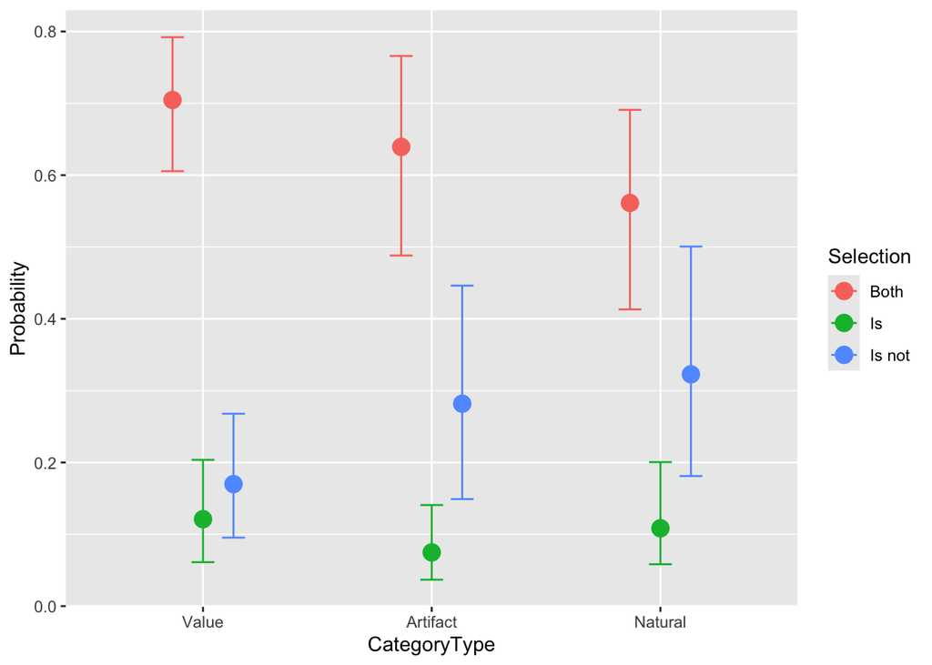

```r
conditional_effects(b2, categorical = TRUE)
```

```r
describe_posterior(b2) %>%
  as_tibble() %>%
  select(-c("CI", "ROPE_CI", "ROPE_low", "ROPE_high")) %>%
  mutate(Parameter = case_when(
    Parameter == "b_muIs_Intercept" ~ "Intercept 'is'",
    Parameter == "b_muIsnot_Intercept" ~ "Intercept 'is not'",
    Parameter == "b_muIs_CategoryTypeArtifact" ~ "Is_CategoryTypeArtifact",
    Parameter == "b_muIs_CategoryTypeNatural" ~ "Is_CategoryTypeNatural",
    Parameter == "b_muIsnot_CategoryTypeArtifact" ~ "Isnot_CategoryTypeArtifact",
    Parameter == "b_muIsnot_CategoryTypeNatural" ~ "Isnot_CategoryTypeNatural"
  )) %>%
  mutate(ESS = round(ESS)) %>%
  knitr::kable(format = "pandoc", digits = 2)
```

| Parameter | Median | CI_low | CI_high | pd | ROPE_Percentage | Rhat | ESS |
| --- | --- | --- | --- | --- | --- | --- | --- |
| Intercept ‘is’ | -1.76 | -2.50 | -1.15 | 1.00 | 0.00 | 1 | 829 |
| Intercept ‘is not’ | -1.42 | -2.08 | -0.85 | 1.00 | 0.00 | 1 | 1241 |
| Is_CategoryTypeArtifact | -0.38 | -0.96 | 0.28 | 0.87 | 0.23 | 1 | 1525 |
| Is_CategoryTypeNatural | 0.13 | -0.48 | 0.90 | 0.65 | 0.40 | 1 | 971 |
| Isnot_CategoryTypeArtifact | 0.60 | -0.03 | 1.21 | 0.97 | 0.07 | 1 | 2840 |
| Isnot_CategoryTypeNatural | 0.88 | 0.24 | 1.49 | 0.99 | 0.00 | 1 | 2847 |

```r
b2_default <- brm(Selection ~ CategoryType + (CategoryType | Participant),
          data=senses_tidy,
          family="categorical")
```

[output not shown]

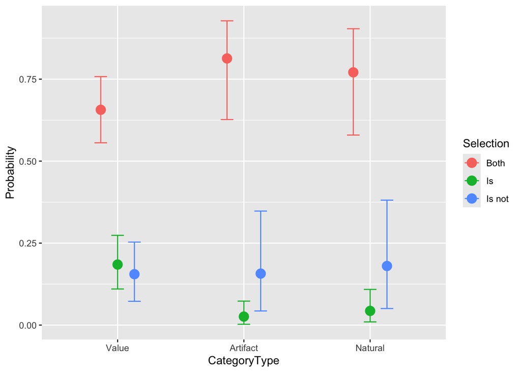

```r
conditional_effects(b2_default, categorical = TRUE)
```

```r
describe_posterior(b2_default) %>%
  as_tibble() %>%
  select(-c("CI", "ROPE_CI", "ROPE_low", "ROPE_high")) %>%
  mutate(Parameter = case_when(
    Parameter == "b_muIs_Intercept" ~ "Intercept 'is'",
    Parameter == "b_muIsnot_Intercept" ~ "Intercept 'is not'",
    Parameter == "b_muIs_CategoryTypeArtifact" ~ "Is_CategoryTypeArtifact",
    Parameter == "b_muIs_CategoryTypeNatural" ~ "Is_CategoryTypeNatural",
    Parameter == "b_muIsnot_CategoryTypeArtifact" ~ "Isnot_CategoryTypeArtifact",
    Parameter == "b_muIsnot_CategoryTypeNatural" ~ "Isnot_CategoryTypeNatural"
  )) %>%
  mutate(ESS = round(ESS))  %>%
  knitr::kable(format = "pandoc", digits = 2)
```

| Parameter | Median | CI_low | CI_high | pd | ROPE_Percentage | Rhat | ESS |
| --- | --- | --- | --- | --- | --- | --- | --- |
| Intercept ‘is’ | -1.27 | -1.87 | -0.76 | 1.00 | 0.00 | 1.00 | 2108 |
| Intercept ‘is not’ | -1.44 | -2.31 | -0.83 | 1.00 | 0.00 | 1.00 | 1550 |
| Is_CategoryTypeArtifact | -2.17 | -4.39 | -1.12 | 1.00 | 0.00 | 1.01 | 709 |
| Is_CategoryTypeNatural | -1.59 | -3.11 | -0.63 | 1.00 | 0.00 | 1.00 | 1723 |
| Isnot_CategoryTypeArtifact | -0.18 | -1.41 | 0.80 | 0.63 | 0.27 | 1.00 | 1454 |
| Isnot_CategoryTypeNatural | 0.02 | -1.25 | 0.96 | 0.51 | 0.28 | 1.00 | 1516 |